# Applications of Quantitative Factor Investing

2024-01-03

This notebook is my personal notes from studying Ch 10. of KAIST MFE Professor Lee Hyun Yul’s *Quant Cookbook with R*.

## Constructing a Sector Neutral Portfolio

One of the drawbacks of portfolio constructing based on factor selection is that you can concentrate your portfolio in certain sectors. And there are valid reasons to avoid such sectors (unfavorable macroeconomic environment, could be exposed to unwanted risks)

### Deviation - Demonstration of group_by() function in R

The most important concept in this section is the usage of `group_by()` function from dplyr. The `group_by()` function in R is used to split a large data set by variables and then apply other functions to gain insights. For instance, consider the simple example below in which the `group_by()` function is used in conjunction with the `summarize()` function in which we input functions like `mean()`, `n()`, `sum()`.

```r
# Load necessary library
library(dplyr)

# Sample sales data
sales_data <- data.frame(
  region = c("North", "South", "North", "East", "South", "East"),
  sales = c(100, 150, 200, 120, 180, 110)
)

# Sum sales per region
total_sales_per_region <- sales_data %>%
  group_by(region) %>%
  summarize(total_sales = sum(sales))
```

The `n()` function counts the number of elements corresponding to the group it belongs to. Take a look at another example below.

```r
# Filter regions with total sales greater than 250
high_sales_regions <- sales_data %>%
  group_by(region) %>%
  filter(sum(sales) > 250)
```

We can use other functions such as `mutate()`, `filter()`, and etc.

One thing to note is that the `group_by()` function alone doesn’t really achieve anything; only when we use it with other functions do we see a change.

Now we go back to the quantitative analysis.

```r
# Import libraries
library(dplyr)
library(xts)
library(PerformanceAnalytics)
library(openxlsx)
library(ggplot2)
library(stringr)
library(tidyverse)
```

Next, we import files. We will be using the following files.

```r
# Import files
KOR_ticker <- read.xlsx("KOR_ticker_2023-04-20.xlsx")
KOR_price <- read.csv("KOR_price/KOR_3Yadjclose_combined.csv", row.names = 1)
KOR_ind <- read.xlsx("KOR_industry_cmp_xl.xlsx")

head(KOR_ind)
```

```
##       X IDX_CD          IDX_NM_KOR ALL_MKT_VAL CMP_CD      CMP_KOR  MKT_VAL
## 1 G25.1    G25 WICS 경기관련소비재   134632603   5380       현대차 26875078
## 2 G25.2    G25 WICS 경기관련소비재   134632603    270         기아 21136456
## 3 G25.3    G25 WICS 경기관련소비재   134632603  12330   현대모비스 14402991
## 4 G25.4    G25 WICS 경기관련소비재   134632603  51900   LG생활건강  6222290
## 5 G25.5    G25 WICS 경기관련소비재   134632603  90430 아모레퍼시픽  4173107
## 6 G25.6    G25 WICS 경기관련소비재   134632603  21240       코웨이  2796046
##     WGT S_WGT CAL_WGT SEC_CD     SEC_NM_KOR SEQ TOP60 APT_SHR_CNT
## 1 19.96 19.96       1    G25 경기관련소비재   1     9   139610794
## 2 15.70 35.66       1    G25 경기관련소비재   2     9   251325275
## 3 10.70 46.36       1    G25 경기관련소비재   3     9    63171013
## 4  4.62 50.98       1    G25 경기관련소비재   4     9     9370918
## 5  3.10 54.08       1    G25 경기관련소비재   5     9    30416235
## 6  2.08 56.16       1    G25 경기관련소비재   6     9    53873722
```

Next, we choose the top 30 stocks based on momentum (12m returns).

```r
# Convert price file to xts object
KOR_price <- as.xts(KOR_price, order.by = as.Date(rownames(KOR_price)))

# Calculate returns
ret <- Return.calculate(KOR_price) %>% xts::last(252)

# Select 30 stocks based on highest 12-month returns
ret_12m <- ret %>% sapply(function(x) prod(1 + x) - 1)
invest_mom_12m <- rank(-ret_12m) <= 30
```

**Notes**

- The reason for converting to an xts object is due to how `Return.calculate()` behaves when used with xts versus a data frame. When used on a data frame, any NA values will result in NA returns. With xts, `Return.calculate()` will ignore NA values.
- Using braces {} around the functional expression in `sapply()` does not change the result.

```r
KOR_ind %>% head()
```

```
##       X IDX_CD          IDX_NM_KOR ALL_MKT_VAL CMP_CD      CMP_KOR  MKT_VAL
## 1 G25.1    G25 WICS 경기관련소비재   134632603   5380       현대차 26875078
## 2 G25.2    G25 WICS 경기관련소비재   134632603    270         기아 21136456
## 3 G25.3    G25 WICS 경기관련소비재   134632603  12330   현대모비스 14402991
## 4 G25.4    G25 WICS 경기관련소비재   134632603  51900   LG생활건강  6222290
## 5 G25.5    G25 WICS 경기관련소비재   134632603  90430 아모레퍼시픽  4173107
## 6 G25.6    G25 WICS 경기관련소비재   134632603  21240       코웨이  2796046
##     WGT S_WGT CAL_WGT SEC_CD     SEC_NM_KOR SEQ TOP60 APT_SHR_CNT
## 1 19.96 19.96       1    G25 경기관련소비재   1     9   139610794
## 2 15.70 35.66       1    G25 경기관련소비재   2     9   251325275
## 3 10.70 46.36       1    G25 경기관련소비재   3     9    63171013
## 4  4.62 50.98       1    G25 경기관련소비재   4     9     9370918
## 5  3.10 54.08       1    G25 경기관련소비재   5     9    30416235
## 6  2.08 56.16       1    G25 경기관련소비재   6     9    53873722
```

```r
KOR_ticker %>% head()
```

```
##   종목코드         종목명     시가총액  종가   대비 등락률 시장구분    업종명
## 1   320000           윈텍 8.990586e+10  4860  -2070 -29.87   KOSDAQ 기계·장비
## 2   145210 다이나믹디자인 1.339975e+11  9490  -2730 -22.34    KOSPI      기계
## 3   010580     에스엠벡셀 3.582307e+11  3220   -730 -18.48    KOSPI  운수장비
## 4   000250     삼천당제약 1.836117e+12 79600 -14600 -15.50   KOSDAQ      제약
## 5   131100   초록뱀이앤엠 8.638862e+10  3080   -560 -15.38   KOSDAQ      유통
## 6   051980     중앙디앤엠 3.065040e+11  4865   -875 -15.24   KOSDAQ      화학
##   EPS PER 선행.EPS 선행.PER  BPS   PBR 주당배당금 배당수익률
## 1  36 135       NA       NA 1141  4.26          0          0
## 2  NA  NA       NA       NA 7920  1.20          0          0
## 3  NA  NA       NA       NA  494  6.52          0          0
## 4  NA  NA       NA       NA 7889 10.09          0          0
## 5  NA  NA       NA       NA 2921  1.05          0          0
## 6  NA  NA       NA       NA 1068  4.56          0          0
```

**Notes on KOR_ind file**

The `SEC_NM_KOR`column contains the sector name and `SEC_CD` contains the sector code, which we will use for this project.

Notice that there are two things we have to modify for:

1. for *CMP_CD*, we must pad the 0s in front of the nonzero digits to restore stock codes, matching those from the ticker file.
2. The order of how these stocks are listed are different for the ticker file and the sector file. Thus, we use `left_join()` to combine these two files by the common columns.

```r
# Pad in the zeros
KOR_ind$CMP_CD <- str_pad(KOR_ind$CMP_CD, 6, "left", pad= 0)

KOR_ind$CMP_CD[1:10]
```

```
##  [1] "005380" "000270" "012330" "051900" "090430" "021240" "008770" "161390"
##  [9] "035250" "383220"
```

```r
# Left join to construct new data.
dt <- left_join(KOR_ticker, KOR_ind,
                by = c('종목코드' = 'CMP_CD',
                        '종목명' = 'CMP_KOR'))

dt %>% head()
```

```
##   종목코드         종목명     시가총액  종가   대비 등락률 시장구분    업종명
## 1   320000           윈텍 8.990586e+10  4860  -2070 -29.87   KOSDAQ 기계·장비
## 2   145210 다이나믹디자인 1.339975e+11  9490  -2730 -22.34    KOSPI      기계
## 3   010580     에스엠벡셀 3.582307e+11  3220   -730 -18.48    KOSPI  운수장비
## 4   000250     삼천당제약 1.836117e+12 79600 -14600 -15.50   KOSDAQ      제약
## 5   131100   초록뱀이앤엠 8.638862e+10  3080   -560 -15.38   KOSDAQ      유통
## 6   051980     중앙디앤엠 3.065040e+11  4865   -875 -15.24   KOSDAQ      화학
##   EPS PER 선행.EPS 선행.PER  BPS   PBR 주당배당금 배당수익률       X IDX_CD
## 1  36 135       NA       NA 1141  4.26          0          0 G45.403    G45
## 2  NA  NA       NA       NA 7920  1.20          0          0 G25.121    G25
## 3  NA  NA       NA       NA  494  6.52          0          0 G25.112    G25
## 4  NA  NA       NA       NA 7889 10.09          0          0  G35.14    G35
## 5  NA  NA       NA       NA 2921  1.05          0          0 G50.114    G50
## 6  NA  NA       NA       NA 1068  4.56          0          0  G20.76    G20
##                IDX_NM_KOR ALL_MKT_VAL MKT_VAL  WGT S_WGT CAL_WGT SEC_CD
## 1                 WICS IT   546771367   53044 0.01 97.76       1    G45
## 2     WICS 경기관련소비재   134632603   93798 0.07 92.23       1    G25
## 3     WICS 경기관련소비재   134632603  100305 0.07 91.59       1    G25
## 4           WICS 건강관리   112938582 1083309 0.96 53.23       1    G35
## 5 WICS 커뮤니케이션서비스   103176113   30236 0.03 93.78       1    G50
## 6             WICS 산업재   148399948  266658 0.18 83.45       1    G20
##           SEC_NM_KOR SEQ TOP60 APT_SHR_CNT
## 1                 IT 403     2    10914497
## 2     경기관련소비재 121     9     9883903
## 3     경기관련소비재 112     9    31150493
## 4           건강관리  14    23    13609408
## 5 커뮤니케이션서비스 114     6     9816888
## 6             산업재  76    22    54811602
```

We verify that the data frame *dt* combines two data frames based on the two columns. Our decision to make the column names from the ticker file the standard preserves the structure + order of the data frame of the ticker file, which is what we desire.

Now we can use the index vector from the ranking methodology to subset the new *dt* file and extract necessary information.

```r
dt[invest_mom_12m,] %>% select('SEC_NM_KOR') %>% group_by(SEC_NM_KOR) %>% summarize(n= n())
```

```
## # A tibble: 5 × 2
##   SEC_NM_KOR         n
##   <chr>          <int>
## 1 IT                10
## 2 건강관리           6
## 3 경기관련소비재     3
## 4 산업재             6
## 5 소재               5
```

**Notes**

The code in the reference book is `group_by("SEC_NM_KOR")`. However, when inputting a character value in the argument of `group_by()` function, we get an undesired outcome (see below).

```r
# Input character value in group_by()
dt[invest_mom_12m,] %>% select('SEC_NM_KOR') %>% group_by('SEC_NM_KOR') %>% summarize(n= n())
```

```
## # A tibble: 1 × 2
##   `"SEC_NM_KOR"`     n
##   <chr>          <int>
## 1 SEC_NM_KOR        30
```

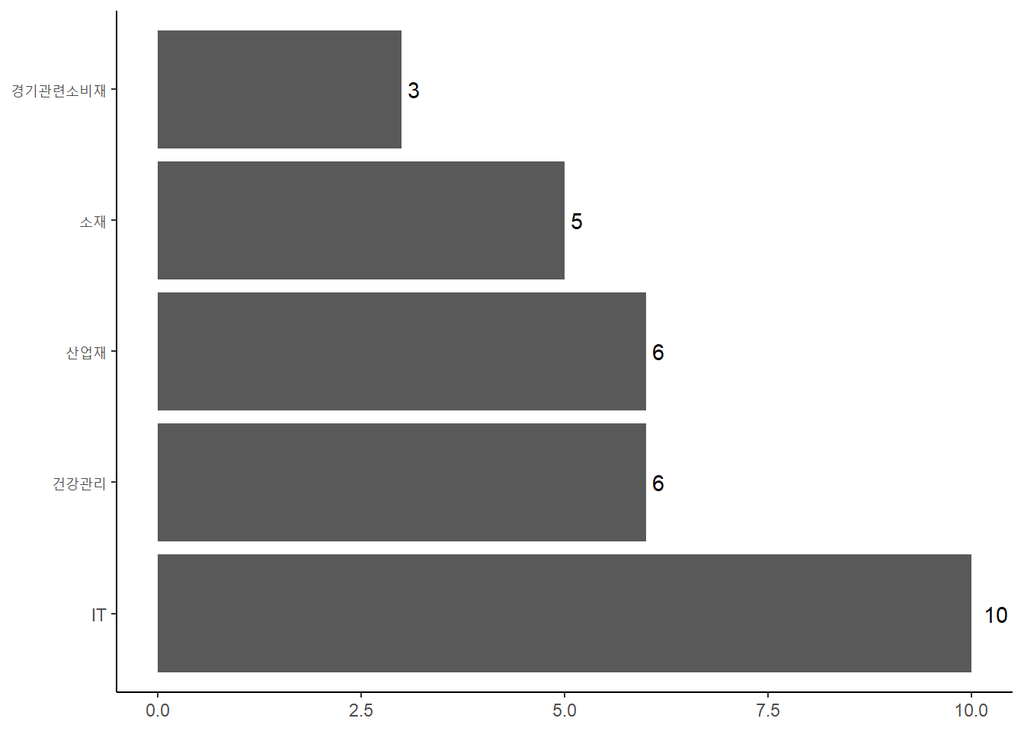

```r
# Visualize number of components in each sector
dt[invest_mom_12m, ] %>%
  select(`SEC_NM_KOR`) %>%
  group_by(SEC_NM_KOR) %>%
  summarize(n = n()) %>%
  ggplot(aes(x = reorder(SEC_NM_KOR, -n),
             y = n, label = n)) +
  geom_col() +
  geom_text(hjust = -0.5) +
  coord_flip() +
  xlab(NULL) +
  ylab(NULL) +
  theme_classic()
```

A bit of subtlety to mention; in the `aes()` function, we specify `label=` parameter as `geom_text()` function looks for the `label` values to display on the chart. Thus, by specifying *n* as the *label* value, we make sure the counts are displayed next to the columns.

### Neutralizing sector effects

Notice that the momentum factor is concentrated in the tech sector. Now, we could in theory decide whether we want our portfolio to be exposed to certain sectors or not. For instance, if we are aware momentum sorted portfolio will be concentrated in some sectors and that we have a positive bias regarding those sectors, we could purposely not neutralize by sector.

However, quants prefer to be agnostic by nature, I think; thus, we could choose to neutralize sector effects.

This is done by grouping all stocks by sectors and standardizing the returns within each sector. Then, even though the 12m return of a stock is high compared to the average of all stocks, if its return is relatively lower compared with its peers in the same sector, then it will receive a lower standardized score. Therefore, we will be in effect forcing a more ‘strict’ standard for stocks that are included in a sector that performs well.

While the grouped scaling will return values for stocks that do not have `SEC_NM_KOR` values, including them in our analysis will be sloppy practice, since we are not scaling by a specific sector, but instead stocks identified as ‘NA’ will be scaled within the NA group. Thus, to prevent ranking these stocks, we will **manually input NA values for stocks that have NA sector names values**.

Now we move on to implementation.`scale()` function will be used to standardize the returns (subtract mean and divide by sdv). Also, we will include both z-scores without sector grouping and z-score with sector grouping, to see the differences.

```r
sector_neutral <- dt %>%
  select(종목코드, 종목명, SEC_NM_KOR) %>%
  mutate(ret = ret_12m, z_score = scale(ret)) %>%
  group_by(SEC_NM_KOR) %>%
  mutate(z_score_sector = scale(ret),
         z_score_sector = ifelse(is.na(SEC_NM_KOR), NA, z_score_sector))

head(sector_neutral)
```

```
## # A tibble: 6 × 6
## # Groups:   SEC_NM_KOR [5]
##   종목코드 종목명         SEC_NM_KOR             ret z_score[,1] z_score_sector
##   <chr>    <chr>          <chr>                <dbl>       <dbl>          <dbl>
## 1 320000   윈텍           IT                  0.0559   0.103            0.0122
## 2 145210   다이나믹디자인 경기관련소비재     -0.0829  -0.0860          -0.111
## 3 010580   에스엠벡셀     경기관련소비재     -0.0196  -0.0000396        0.00381
## 4 000250   삼천당제약     건강관리            0.545    0.767            0.855
## 5 131100   초록뱀이앤엠   커뮤니케이션서비스 -0.253   -0.318           -0.0440
## 6 051980   중앙디앤엠     산업재              2.91     3.98             4.00
```

#### NA Analysis

```r
# NA values for returns
sum(is.na(sector_neutral$ret))
```

```
## [1] 55
```

```r
NA_ret <- which(is.na(sector_neutral$ret))

# NA values for SEC_NM_KOR
sum((is.na(sector_neutral$SEC_NM_KOR)))
```

```
## [1] 56
```

```r
NA_SEC_name <- which(is.na(sector_neutral$SEC_NM_KOR))

intersect(NA_ret, NA_SEC_name)
```

```
## [1] 2336
```

In total, there are 110 distinct data points among 2336 observations that are not usable. While we do not take action, in reality, we would review the data series of these stocks and determine what the effects of not including these names in our portfolio.

```r
sum((is.na(sector_neutral$z_score_sector)))
```

```
## [1] 110
```

Indeed, we confirm that total NA counts for our sector-neutralized z-score is 110.

Now, we use the sector-neutralized z-score to rank momentum stocks and construct our new portfolio.

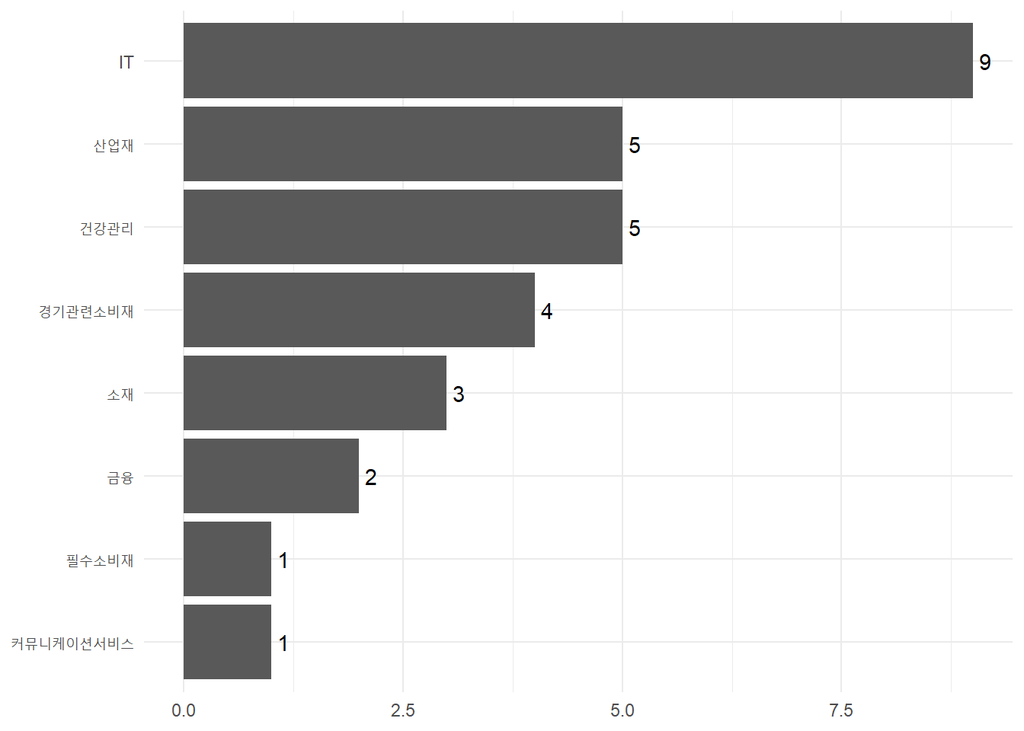

```r
# Rank using sector-neutralized z-score
invest_mom_neutralized <- rank(-sector_neutral$z_score_sector) <= 30

# Use logical vector to subset data set
sector_neutral[invest_mom_neutralized,] %>%
  group_by(SEC_NM_KOR) %>%
  summarize(n = n()) %>%
  ggplot(aes(x = reorder(SEC_NM_KOR, n), y = n, label =n)) +
  geom_col() +
  geom_text(hjust = -0.5) +
  theme_minimal() +
  coord_flip() +
  xlab(NULL) +
  ylab(NULL)
```

We see that the new portfolio is less concentrated, though we still invest in nine names from the tech sector.

### Imposing a max constraint on sector concentration

If for some reason, we have a very strong reason to not concentrate on a a specific sector, we could impose a maximum constraint (for instance, we would like to restrict ourself from investing more than 5 names per sector) and proceed to invest in the next best ranks.

For methodology, we could use the `group_by()` function to select the 5 lowest ranks per sector and output a subset of the original data set that has five best performing stocks (in terms of factor) for each sector. Then among these selected stocks, we select the 30 lowest ranked stocks.

The code `sector_neutral %>% mutate(ranked = rank(-sector_neutral$z_score_sector))` does not work on its own because `sector_neutral` is a grouped data frame. Thus, mutate() automatically applies group-wise. Hence, we must ungroup the data set first.

```r
# Ungroup df
sector_neutral_ungrouped <- ungroup(sector_neutral)

# Create new column
sector_neutral_constraint <- sector_neutral_ungrouped %>% mutate(ranked = rank(-sector_neutral$z_score_sector))
```

Notice `rank()` function will also rank the NA values but rank them last.

Next, we extract the five lowest ranked names within each sector using `group_by()` function and `slice_min()`.

```r
# Extract five best per sector
sector_neutral_constraint <- sector_neutral_constraint %>%
  group_by(SEC_NM_KOR) %>%
  slice_min(ranked, n = 5) %>%
  ungroup()

sector_neutral_constraint <- sector_neutral_constraint[rank(sector_neutral_constraint$ranked) <= 30,]
head(sector_neutral_constraint)
```

```
## # A tibble: 6 × 7
##   종목코드 종목명         SEC_NM_KOR   ret z_score[,1] z_score_sector ranked
##   <chr>    <chr>          <chr>      <dbl>       <dbl>          <dbl>  <dbl>
## 1 139050   시티랩스       IT          7.75       10.6           11.1       2
## 2 007660   이수페타시스   IT          4.04        5.51           5.76     10
## 3 022100   포스코DX       IT          3.79        5.17           5.40     12
## 4 317770   슈프리마아이디 IT          3.66        5.00           5.22     14
## 5 058970   엠로           IT          3.65        4.98           5.20     15
## 6 322510   제이엘케이     건강관리    5.31        7.24           7.82      7
```

Now we view the counts to see whether we have accomplished our objective of putting a cap on sector concentration

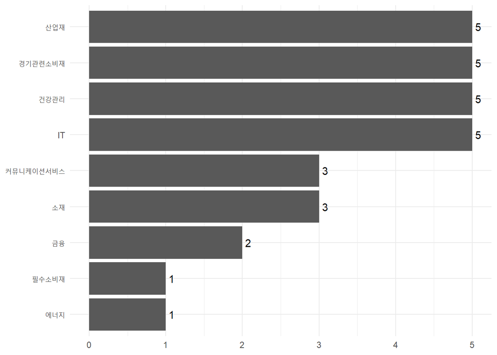

```r
# ggplot of bar count
sector_neutral_constraint %>%
  group_by(SEC_NM_KOR) %>%
  summarize(n = n()) %>%
  ggplot(aes(x = reorder(SEC_NM_KOR, n), y = n, label =n)) +
  geom_col() +
  geom_text(hjust = -0.5) +
  theme_minimal() +
  coord_flip() +
  xlab(NULL) +
  ylab(NULL)
```

Notice with this cap, we have successfully capped out concentration at max five names per sector. Whether this methodology produces higher risk-adjusted returns in the long run compared to the unconstrained method is another subject.

## Joel Greenblatt’s Magic Formula

Next, we look at a portfolio combining value and quality factors. The idea is as simple as it sounds. There are fundamentally sound reasons why looking into stocks with good quality and value score, as we may be able to screen out potential value traps (in contrast to sorting portfolios solely based on value factor) and over valued stocks (in contrast to sorting portfolios solely based on quality factor).

One of the main value + quality portfolio samples is oen constructed using the *magic formula* advocated by famous investor Joel Greenblatt.

### Relationship between quality and value factor

First, we want to see what are the possible implications of using a combination of value and quality score to construct a portfolio.

Thus, we first look at basic relationships between those two factors.

```r
# Import financial statements data sheet and valuation data
KOR_value <- read.csv("KOR_valuation_clean.csv")
KOR_fs <- readRDS("KOR_fs_clean.Rds")

KOR_value$X <- str_pad(KOR_value$X, 6,"left", 0)
```

#### Spearman vs Pearson

It might not be appropriate to find the pearson correlation between *GPA*, a quality factor, and *PBR*, a value factor, as both are on different scales. Instead, we could try to find the z-score of these two factors and then calculate the pearson correlation, or find the spearman correlation (pearson correlation between ranking values).

##### Raw correlation vs z-score correlation

When calculating *GPA* scores, we have to take into account that depending on the date we have collected data, the availability of most recent data differs.

Specifically, if we are in one of Jan, Feb, March, or April, we have to use data from two years ago.

```r
# Create data frame with stock code and PBR
dt <- KOR_value %>% select(X, PBR)

# Check stock code columns are equivalent for KOR_fs and KOR_value spreadsheets
identical(KOR_fs[[1]]$stockcode, KOR_value$X)
```

```
## [1] TRUE
```

```r
head(dt)
```

```
##        X       PBR
## 1 320000  1.984380
## 2 145210  1.828110
## 3 010580  3.520205
## 4 000250  7.466654
## 5 131100        NA
## 6 051980 10.249897
```

```r
# Set num_col depending on date of data collection
years_elapsed_since_2023 = 2
if ( lubridate::month(Sys.Date()) %in% c(1,2,3,4) ) {
  num_col = str_which(colnames(KOR_fs[[1]]), as.character(lubridate::year(Sys.Date()) - 2 - years_elapsed_since_2023)) # Since data was collected in 2023, subtract additional 2 years
} else {
  num_col = str_which(colnames(KOR_fs[[1]]), as.character(lubridate::year(Sys.Date()) - 1 - years_elapsed_since_2023))
}

# Subtract 1 from num_col to account for the exclusion of character column
num_col <- num_col - 1
num_col
```

```
## [1] 2
```

```r
# Calculate and append GPA to dt
gpa_score <- (KOR_fs[['매출총이익']][-1] / KOR_fs[['자산']][-1])[num_col]

dt <- cbind(dt, gpa_score)

colnames(dt) <- c("stock code", "PBR", "GPA")

head(dt)
```

```
##   stock code       PBR          GPA
## 1     320000  1.984380  0.121951220
## 2     145210  1.828110 -0.009482759
## 3     010580  3.520205 -0.027196653
## 4     000250  7.466654  0.241640012
## 5     131100        NA           NA
## 6     051980 10.249897  0.015473888
```

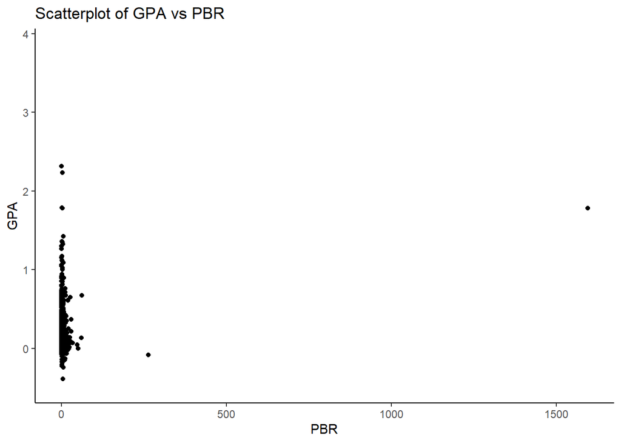

```r
# Raw pearson correlation and visualization

dt %>% ggplot(aes(x = PBR, y = GPA)) +
  geom_point() +
  ggtitle("Scatterplot of GPA vs PBR") +
  theme_classic()
```

Just from looking at the scatterplot, we can see why pearson’s correlation applied to raw PBR and GPA variables can produce useless results; the outliers have too much influence on the linear relationship.

We could try to exclude the two outlier points and try plotting again.

Incorporating the fact that there are 49 NA values, we use order function to find the largest two PBR values and input NA

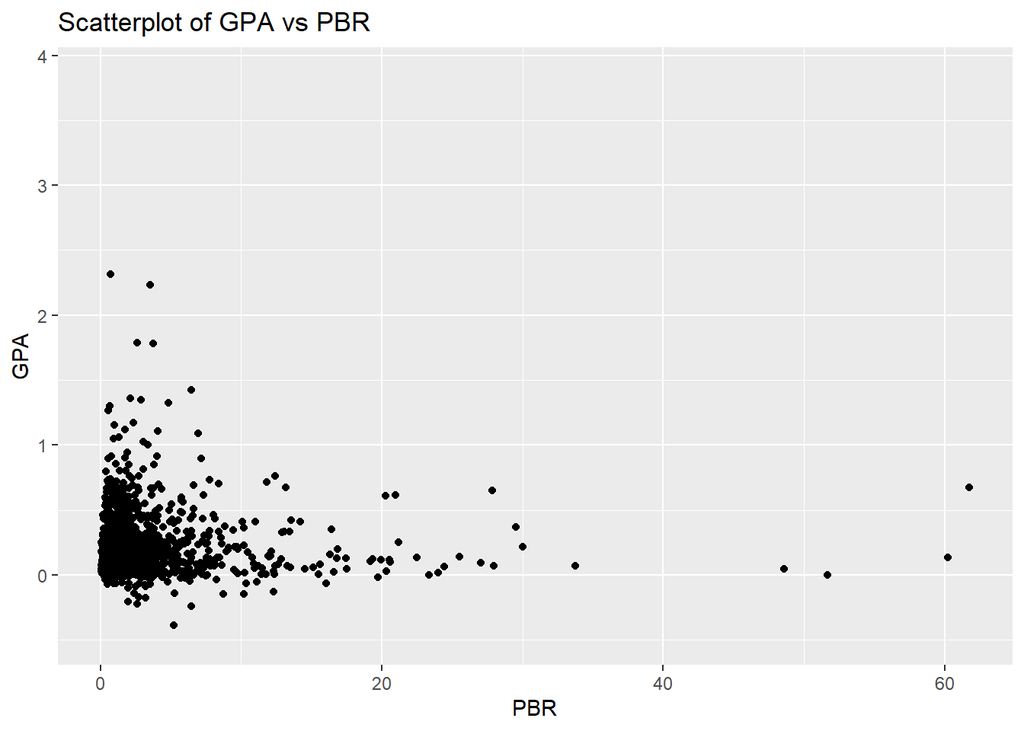

```r
# outlier boolean index
dt %>% arrange(desc(dt$PBR)) %>% slice(-1:-2) %>%
  ggplot(aes(x = PBR, y = GPA)) +
  geom_point() +
  ggtitle("Scatterplot of GPA vs PBR")
```

```r
# Compute pearson correlation of PBR and GPA
cor(dt$PBR, dt$GPA, method = "pearson", use = "complete.obs")
```

```
## [1] 0.1672611
```

Still, it is evident that using raw values is inappropriate for comparison.

Now we look at the z-score.

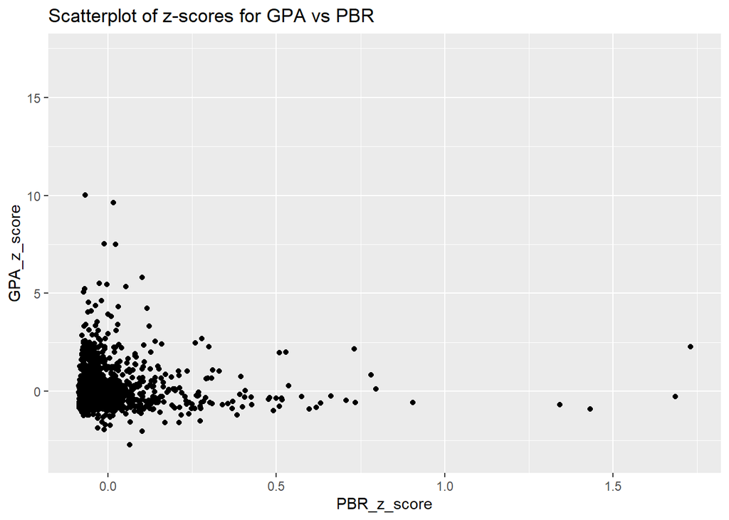

```r
# Append z-scores for PBA and GPA
dt_z_score <- data.frame(
  stock_code = dt$'stock code',
  PBR_z_score = scale(dt$PBR),
  GPA_z_score = scale(dt$GPA)
  )

# Remove outliers and plot ggplot
dt_z_score %>% arrange(desc(PBR_z_score)) %>% slice(-1:-2) %>%
  ggplot(aes(x = PBR_z_score, y = GPA_z_score)) +
  geom_point() +
  ggtitle("Scatterplot of z-scores for GPA vs PBR")
```

z-scores don’t seem to help that much in this case as well.

```r
# Compute pearson correlation between z-scores and exclude NA values
cor(dt_z_score$PBR_z_score, dt_z_score$GPA_z_score, method = "pearson", use = "complete.obs")
```

```
## [1] 0.1672611
```

Obvious only when thinking about it mathematically, correlation is just the average of z-scores, so taking correlation of z-scores is essentially the same as taking correlation of the original pair.

##### Spearman correlation

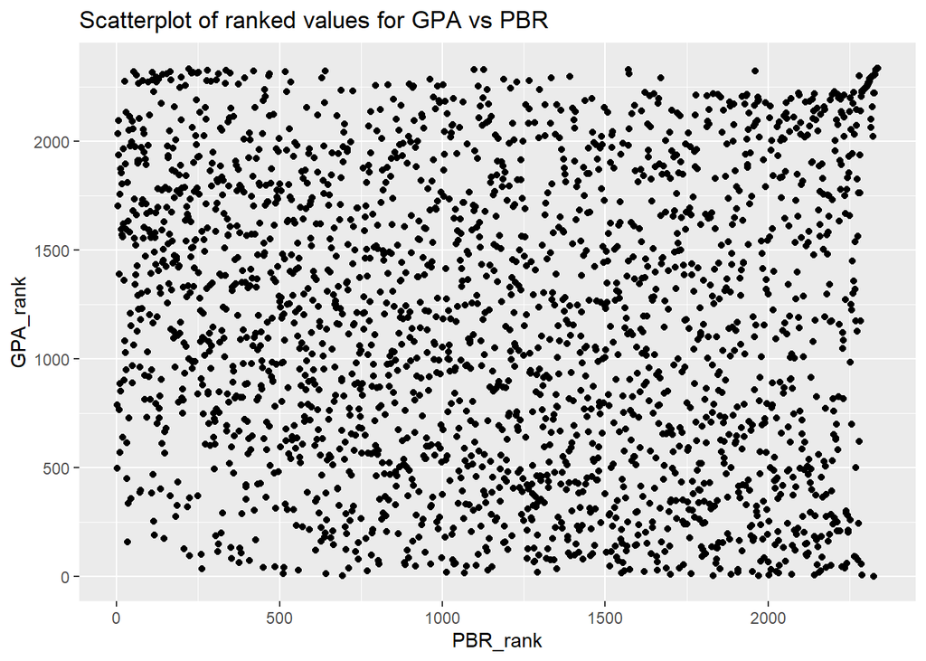

```r
# Plot ranked values
dt_rank <- data.frame(
  stock_code = dt$`stock code`,
  PBR_rank = rank(dt$PBR),
  GPA_rank = rank(-dt$GPA))

dt_rank %>% ggplot(aes(x = PBR_rank, y = GPA_rank)) +
  geom_point() +
  ggtitle("Scatterplot of ranked values for GPA vs PBR")
```

```r
# Compute spearman correlation
cor(dt$PBR, -dt$GPA, method = 'spearman', use = 'complete.obs') %>% round(4)
```

```
## [1] -0.0951
```

```r
cor(dt_rank$PBR_rank, dt_rank$GPA_rank, method = 'pearson', use = 'complete.obs') %>% round(4)
```

```
## [1] -0.0656
```

##### Visualization of PBR and GPA relationship using quantile summaries

Next, we will divide PBR to quantiles and find the average GPA corresponding to each PBR quantile. We use bar plots to visualize mean_gpa corresponding to each quantile to see whether there is a monotonic relationship between PBR and GPA.

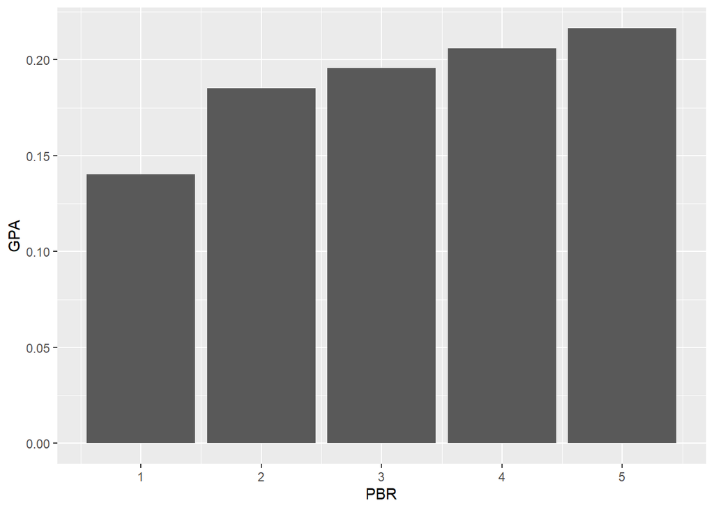

```r
dt %>%
  mutate(quantile_pbr = ntile(PBR, 5)) %>%
  filter(!is.na(quantile_pbr)) %>%
  group_by(quantile_pbr) %>%
  summarise(mean_gpa = mean(GPA, na.rm = TRUE)) %>%
  ggplot(aes(x = quantile_pbr, y = mean_gpa)) +
  geom_col() +
  xlab('PBR') + ylab('GPA')
```

We see that as stocks corresponding to lower PBR (belonging to 1st quantile) have lower mean GPA scores. That is, a value stock tends to have low quality score (measured using GPA).

Now we go back to actually constructing a portfolio based on the *magic formula*.

### Constructing long-only portfolio based on magic formula

There are two important metrics to consider:

1. Earnings yield (representing value of stock)
2. Return on Capital (representing quality of stock)

Some important caveats of the magic formula:

- Many investors use PER instead of earnings yield and ROE instead of ROC, due to insufficient data
- Return on capital is a subjective measure whose precise calculation depending on the investor calculating the metric

However, we can construct the original magic formula portfolio using data we have collected.

#### Earnings Yield

First, when calculating earnings yield or return on capital, we need to decide on the return metric to use for the numerator. Usually, we use
$$NOPAT = EBIT(1-t)$$
where t is the marginal tax rate.

To calculate Earnings yield, the denominator is enterprise value, or EV.

$$EV = \text{market value of equity} +
\text{market value of debt} - cash$$

is usually how we calculate EV, based on Aswath Damodaran.

In our case, we will define EV as market value of equity plus net debt, where net debt is defined as total debt - leftover cash. Leftover cash is residual cash after subtracting (-non-cash working capital); that is, if non-cash working capital is negative, we subtract this quantity from cash to get residual cash. This residual cash is indeed the leftover cash.

$$\text{residual cash} = 현금 - max(0,
유동부채 - 유동자산 + 현금)$$

이익수익률 = (이자 및 법인세 차감전이익) / (시가총액 + 총부채 - 여유 자금)

이익수익률 = (이자 및 법인세 차감전이익) / (시가총액 + 총부채 - max(0, 유동부채 - 유동자산 +현금))

is how we calculate it.

```r
library(stringr)
library(dplyr)
```

```r
# Set num_col depending on date of data collection
if ( lubridate::month(Sys.Date()) %in% c(1,2,3,4) ) {
  num_col = str_which(colnames(KOR_fs[[1]]), as.character(lubridate::year(Sys.Date()) - 2 - years_elapsed_since_2023))
} else {
  num_col = str_which(colnames(KOR_fs[[1]]), as.character(lubridate::year(Sys.Date()) - 1 - years_elapsed_since_2023))
}

# subtract 1 from num_col to reflect that 1st column is character column. When we apply arithmetic operations later, we will have to disregard the 1st column
num_col <- num_col - 1
num_col
```

```
## [1] 2
```

```r
# Calculate EBIT
magic_ebit <- (KOR_fs$"당기순이익"[-1] + KOR_fs$"법인세비용"[-1] + KOR_fs$"이자비용"[-1])[num_col]

# Calculate EV
magic_MV_equity <- KOR_value$PER * KOR_fs$'당기순이익'[num_col+1]
magic_debt <- KOR_fs$"부채"[num_col + 1]
magic_excess_cash1 <-  (KOR_fs$'현금및현금성자산'[-1] - (KOR_fs$"유동자산"[-1] - KOR_fs$"유동부채"[-1]))[num_col]
magic_excess_cash1[magic_excess_cash1 < 0] <- 0
magic_excess_cash2 <- KOR_fs$현금및현금성자산[num_col + 1] - magic_excess_cash1

magic_EV <- magic_MV_equity + magic_debt - magic_excess_cash2

# Earnings Yield
magic_EY = magic_ebit / magic_EV
```

**Note**

- There are 1111 NA values, where most of them are produced from the NA values regarding PER data. There are over 1000 data points with NA values regarding PER data. I believe the reason for this is because I used “지배주주순이익” instead of “당기순이익” when setting the numerator, when in fact the former financial account is missing for most stocks.
- Realizing above point, we should collect data again regarding valuation ratios by using “당기순이익” instead of “지배주주순이익”.

#### Return on Capital (ROC)

Invested capital usually excludes non-interest bearing liabilities from total assets. Or we could add net debt (interest bearing liability - cash) to BV of equity. Whatever we do, the fundamental idea of invested capital is **the book value of total operating assets**.

The formula advocated by Aswath Damodaran is:
$$IC = \text{BV of equity} + \text{BV of debt} -
Cash$$

```r
# Calculate ROC
magic_ic = ((KOR_fs$'유동자산'[-1] - KOR_fs$'유동부채'[-1]) +
              (KOR_fs$'비유동자산'[-1] - KOR_fs$'감가상각비'[-1]))[num_col]
magic_roc = magic_ebit / magic_ic
```

Next, we rank portfolios by magic formula and construct our long-only portfolios. We simply rank the summation of the ranked values for each factor.

Also, higher roc and earnings yield imply higher risk premium, so we rank the negative values.

```r
# Rank portfolio
invest_magic <- (rank(rank(-magic_roc) + rank(-magic_EY))) <= 30

# Check portfolio constituents

KOR_ticker[invest_magic,] %>% select('종목코드', '종목명', '시가총액', '업종명') %>%
  mutate(earnings_yield = round(magic_EY[invest_magic,], 4),
         roc = round(magic_roc[invest_magic,], 4)
  )
```

```
##      종목코드           종목명     시가총액        업종명 earnings_yield    roc
## 50     042600         새로닉스 7.069014e+11        IT부품         0.1575 0.3333
## 170    215000           골프존 7.066117e+11    소프트웨어         0.2129 0.3297
## 173    106240     파인테크닉스 4.116110e+10        IT부품         0.4223 0.2446
## 188    298540   더네이쳐홀딩스 4.363397e+11     섬유·의류         0.2004 0.2868
## 227    094970         제이엠티 6.548562e+10        IT부품         0.3044 0.2522
## 295    205470         휴마시스 4.618688e+11          제약         0.7886 0.9685
## 343    084650       랩지노믹스 2.412800e+11    기타서비스         0.1833 0.6787
## 432    058630           엠게임 1.774584e+11  디지털컨텐츠         0.2645 0.3325
## 507    225590       패션플랫폼 3.856996e+10     섬유·의류         0.2402 0.2952
## 530    108320         LX세미콘 1.665464e+12      전기전자         0.1870 0.4806
## 629    083450              GST 2.329436e+11        반도체         0.2463 0.3179
## 652    000990         DB하이텍 2.925867e+12      전기전자         0.2716 0.3935
## 771    084010         대한제강 3.388926e+11      철강금속         0.2861 0.3109
## 802    078350       한양디지텍 1.727188e+11        반도체         0.1675 0.3825
```

[output cut: 16 more lines]

## Handling outliers and Combining Factors

Now, when we construct factor portfolios, it is inevitable to confront with outlier names. For instance, is it always good to include a stock that had 1000% return over the past 12 months? Or is it good that a company’s ROE is 100%?

Definitely, we have to make discretionary decisions when confronting these issues. Hence, before we make these decisions, we first identify these outliers.

```r
library(magrittr)
library(ggplot2)

# Read valuation data
KOR_value <- KOR_value <- read.csv("KOR_valuation_clean.csv")

rownames(KOR_value) <- KOR_value$X
KOR_value <- select(KOR_value, -1)
head(KOR_value)
```

```
##              PER       PBR       PCR       PSR
## 320000        NA  1.984380  22.52271  2.218986
## 145210        NA  1.828110        NA  1.532848
## 10580   25.63628  3.520205  53.60312  1.724077
## 250    316.17416  7.466654 137.88046 10.342979
## 131100        NA        NA        NA        NA
## 51980         NA 10.249897        NA  7.432056
```

```r
# Check max and min
cat("PER:", max(KOR_value$PER, na.rm = TRUE),"\n",
    "PBR:",max(KOR_value$PBR, na.rm = TRUE) , "\n",
    "PCR:", max(KOR_value$PCR, na.rm = TRUE)
    )
```

```
## PER: 4153.131
##  PBR: 1594.588
##  PCR: 23343.11
```

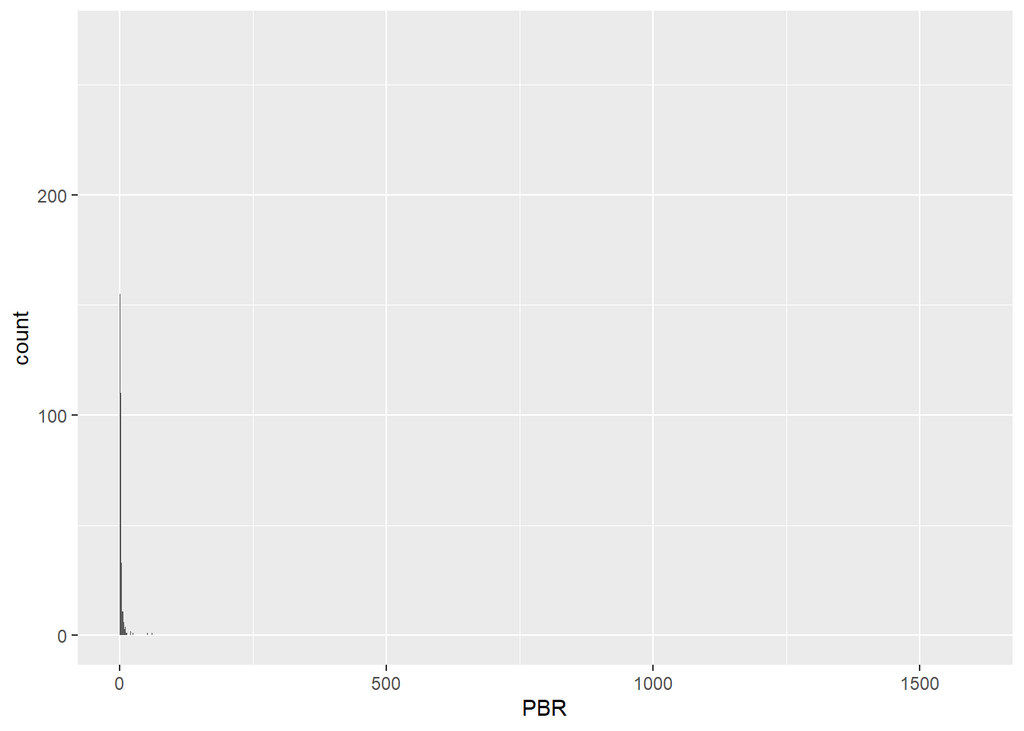

```r
# Visualize histogram
KOR_value %>%
  ggplot(aes(x = PBR)) +
  geom_histogram(binwidth = 0.2)
```

The reason why the tail is stretched to the right side is that we have a stock name that has a PBR higher than 1500.

### Trimming: Deleting Outliers

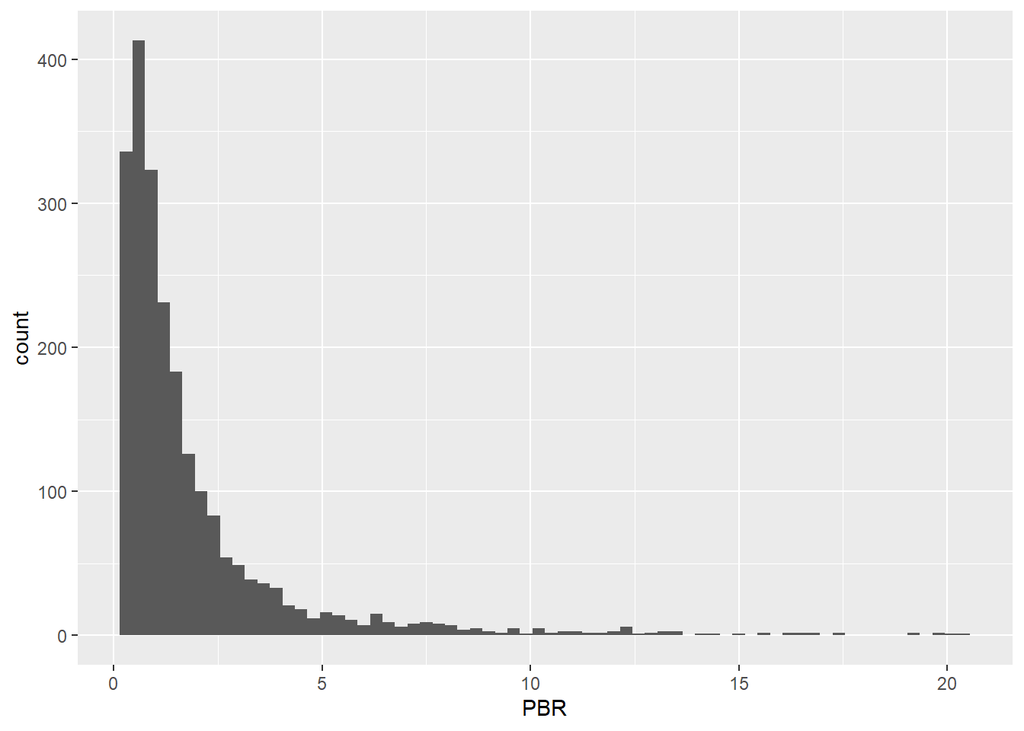

```r
# Use percent_rank() to trim top and bottom 1% values
value_trim <- KOR_value %>% select(PBR) %>%
  mutate(PBR = ifelse(percent_rank(PBR) < 0.01, NA, PBR),
         PBR = ifelse(percent_rank(PBR) >0.99, NA, PBR)
         )

value_trim %>% ggplot(aes(x = PBR)) +
  geom_histogram(binwidth = 0.3)
```

### Winsorizing: Replace outliers

Another common way is to set a threshold on each tailside (e.g., 1% and 99%) and replace values that exceed these thresholds with the threshold values (i.e., 1% and 99% percentile values).

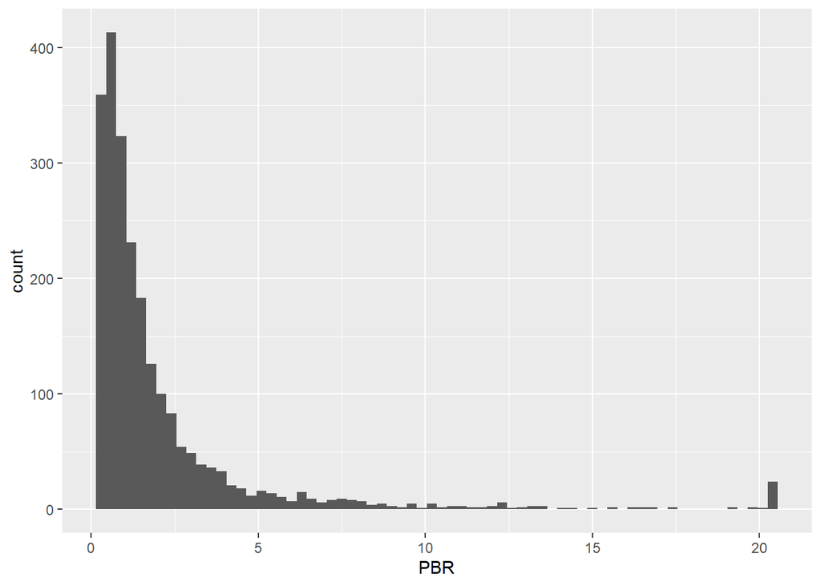

```r
# Winsorize using 1% and 99% threshold values
value_winsorize <- KOR_value %>% select(PBR) %>%
  mutate(PBR = ifelse(percent_rank(PBR) < 0.01, quantile(., 0.01, na.rm = TRUE), PBR),
         PBR = ifelse(percent_rank(PBR) > 0.99, quantile(., 0.99, na.rm = TRUE), PBR)
         )

value_winsorize %>% ggplot(aes(x = PBR)) +
  geom_histogram(binwidth = 0.3)
```

Compared with the trimming method, we see that there is an increase in extreme values (long histogram).

### Combining multiple factors

When constructing factor portfolios, adding ranks have its own pros as they nullify extreme values.

However, adding ranks can be troublesome when you want to seriously manage money.

That usually occurs when you have distorted NA values for each data set. This is confirmed in the next visual.

```r
KOR_value %>%
  mutate_all(list(~min_rank(.))) %>%
  head()
```

```
##         PER  PBR  PCR  PSR
## 320000   NA 1649 1106 1618
## 145210   NA 1590   NA 1403
## 10580   919 1969 1323 1465
## 250    1243 2171 1441 2082
## 131100   NA   NA   NA   NA
## 51980    NA 2215   NA 2030
```

```r
KOR_value %>%
  mutate_all(list(~rank(.))) %>%
  head()
```

```
##         PER  PBR  PCR  PSR
## 320000 1262 1649 1106 1618
## 145210 1263 1590 1498 1403
## 10580   919 1969 1323 1465
## 250    1243 2171 1441 2082
## 131100 1264 2288 1499 2224
## 51980  1265 2215 1500 2030
```

```r
KOR_value %>%
  mutate_all((list(~rank(., ties.method = "min")))) %>%
  head()
```

```
##         PER  PBR  PCR  PSR
## 320000 1262 1649 1106 1618
## 145210 1263 1590 1498 1403
## 10580   919 1969 1323 1465
## 250    1243 2171 1441 2082
## 131100 1264 2288 1499 2224
## 51980  1265 2215 1500 2030
```

We see that `min_rank()` method does not parse NA values; that is, it doesn’t rank NA values, unlike `rank()`.

We use `min_rank()` in order to visualize the caveats of adding ranks of data vectors with varying NA values.

```r
KOR_value %>%
  mutate_all(list(~min_rank(.))) %>%
  pivot_longer(c(PER, PBR, PSR, PCR), names_to = "metric", values_to = "value") %>% head()
```

```
## # A tibble: 6 × 2
##   metric value
##   <chr>  <int>
## 1 PER       NA
## 2 PBR     1649
## 3 PSR     1618
## 4 PCR     1106
## 5 PER       NA
## 6 PBR     1590
```

Next, we apply `pivot_longer` to convert from wide to long format, organizing into a two-column data frame with key-value pairs.

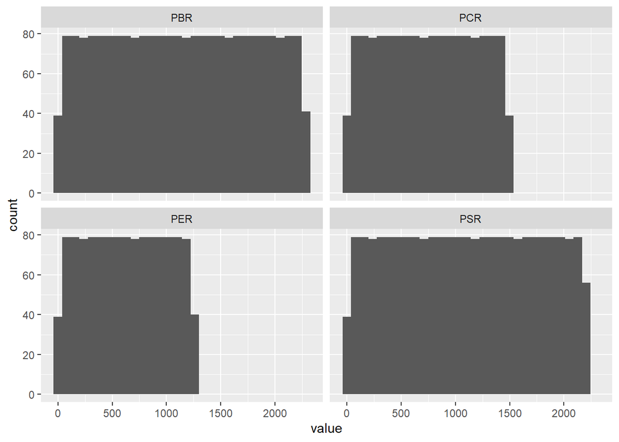

```r
KOR_value %>%
  mutate_all(list(~min_rank(.))) %>%
  pivot_longer(c(PER, PBR, PSR, PCR), names_to = "metric", values_to = "value") %>%
  ggplot(aes(x = value)) +
  geom_histogram() +
  facet_wrap(~metric)
```

As we can see above, PBR and PSR values do not suffer from too many missing data, while PCR and PER have many less data points from missing observation.

**Notes**

- We used `mutate_all()` here since we want to apply a function to *all* the columns of data frame.
- `list()` inside of the `mutate_all()` is there if we want to apply a list of functions to the columns.
- `~` notation is a foreshadow that instructs R that the superceding code will be an anonymous function.
- `gather()` is used to transform wide to long format, which is more adapt for using ggplot.
- `face_wrap()` is used to create multiple panels within the graph, separated by *key* values.

Now, to remedy above phenomenon, we find the z-score of these ranks. This will unify the x-scale once again while at the same time maintaining the ordered property of the current features.

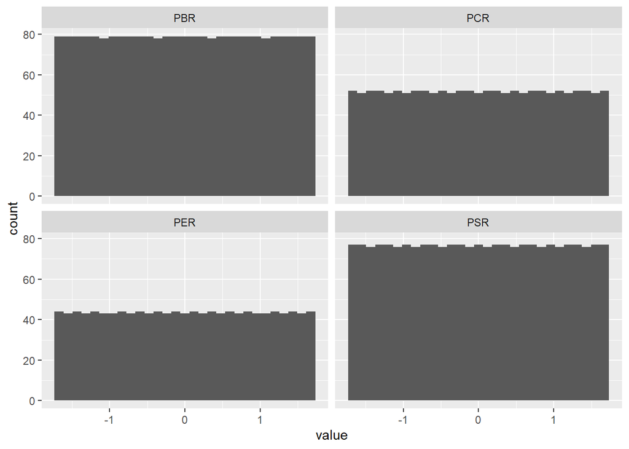

```r
KOR_value %>%
  mutate_all(list(~min_rank(.))) %>%
  mutate_all(list(~scale(.))) %>%
  pivot_longer(c(PER, PBR, PSR, PCR), names_to = "metric", values_to = "value") %>%
  ggplot(aes(x = value)) +
  geom_histogram() +
  facet_wrap(. ~metric)
```

We see that the x-axis is unified. Now we can add these z-scores to find multi-factor portfolios.

### Multi Factor Portfolio Construction

Finally, we use following measurements to construct multifactors.

- **Quality**: ROE, Gross Margin, Operating Cash Flow
- **Value**: PBR, PER, PSR, PCR
- **Momentum**: 3 month return, 6 month return, 12 month return

For this section, we will use following data sheets.

- KOR_fs: financial statements for all publicly listed companies
- KOR_value: PBR, PCR, PSR, and PER values
- KOR_price: price series for all publicly listed companies
- KOR_ticker: ticker data

```r
library(xts)
library(tidyverse)
library(openxlsx)
```

```r
# Import all data sheet
KOR_ticker <- read.xlsx("KOR_ticker_2023-04-20.xlsx")
KOR_price <- read.csv("KOR_price/KOR_3Yadjclose_combined.csv", row.names = 1) %>% as.xts()
KOR_value <- read.csv("KOR_valuation_clean.csv")
KOR_fs <- readRDS("KOR_fs_clean.Rds")

# Pad zeros and set stock code column as rownames
KOR_value$X <- str_pad(KOR_value$X, 6, side = "left", 0)
rownames(KOR_value) <- KOR_value$X
KOR_value <- KOR_value %>% select(-X)

# Set stock code vector for each element of KOR_fs as rownames
KOR_fs <- KOR_fs %>% lapply(function(x){
  x <- select(x, -"stockcode")
})
```

One thing to note: tibble doesn’t support rownames, so if you want to use rownames, you have to use the plain data frame type.

```r
# Set num_col depending on date of collection
if (month(Sys.Date()) %in% c(1,2,3,4)) {
  num_col <- str_which(colnames(KOR_fs[[1]]), as.character(year(Sys.Date()) -2 - years_elapsed_since_2023))} else {num_col <- str_which(colnames(KOR_fs[[1]]), as.character(year(Sys.Date()) -1 - years_elapsed_since_2023))}

num_col
```

```
## [1] 2
```

```r
# Find Quality measures
quality_roe = (KOR_fs$'당기순이익' / KOR_fs$'자본')[num_col]
quality_gpa = (KOR_fs$'매출총이익' / KOR_fs$'자산')[num_col]
quality_cfo =
  (KOR_fs$'영업활동으로인한현금흐름' / KOR_fs$'자산')[num_col]

# Bind results
quality_comb <- tibble(ROE = quality_roe[,1], GPA = quality_gpa[,1], CFO = quality_cfo[,1])
quality_comb %>% head()
```

```
## # A tibble: 6 × 3
##       ROE      GPA     CFO
##     <dbl>    <dbl>   <dbl>
## 1  0.0332  0.122    0
## 2 -0.617  -0.00948  0.0129
## 3 -0.512  -0.0272  -0.0669
## 4 -0.0416  0.242   -0.0224
## 5 NA      NA       NA
## 6 -0.467   0.0155  -0.0735
```

```r
# Convert to ranks
factor_quality <- quality_comb %>%
  transmute(across(c(ROE, GPA, CFO), list(rank = ~min_rank(desc(.)), naive_scale = ~scale(.)), .names = "{.col}_{.fn}")) %>%
  mutate(across(ends_with("_rank"), ~scale(.), .names = "{.col}_scale")) %>%
  mutate(
    naive_score = rowSums(across(ends_with("_naive_scale"), ~replace_na(., 0))),
    rank_score = rowSums(across(ends_with("_rank"), ~replace_na(., 0))),
    rank_scale_score = rowSums(across(ends_with("_rank_scale"), ~replace_na(., 0)))
  )

head(factor_quality)
```

```
## # A tibble: 6 × 12
##   ROE_rank ROE_naive_scale[,1] GPA_rank GPA_naive_scale[,1] CFO_rank
##      <int>               <dbl>    <int>               <dbl>    <int>
## 1     1408            0.000998     1284              -0.322     1495
## 2     2208           -0.196        2164              -0.941     1355
## 3     2183           -0.165        2183              -1.02      1977
## 4     1776           -0.0217        528               0.242     1739
## 5       NA           NA              NA              NA           NA
## 6     2169           -0.151        2076              -0.824     2012
## # ℹ 7 more variables: CFO_naive_scale <dbl[,1]>, ROE_rank_scale <dbl[,1]>,
## #   GPA_rank_scale <dbl[,1]>, CFO_rank_scale <dbl[,1]>, naive_score <dbl>,
## #   rank_score <dbl>, rank_scale_score <dbl>
```

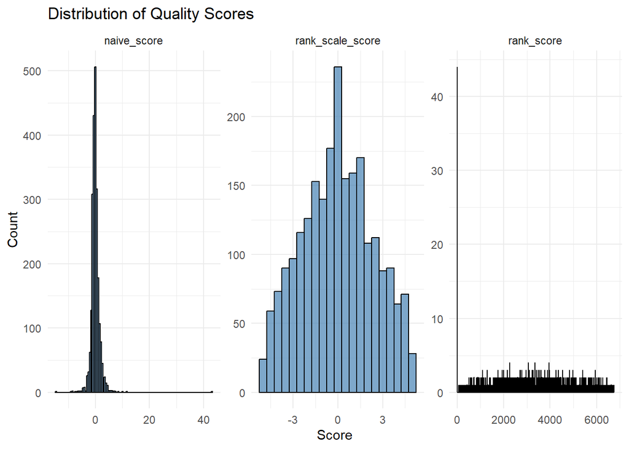

```r
factor_quality %>%
  select(naive_score, rank_score, rank_scale_score) %>%
  pivot_longer(everything(), names_to = "Metric", values_to = "Score") %>%
  ggplot(aes(x = Score)) +
  geom_histogram(binwidth = 0.5, fill = "steelblue", color = "black", alpha = 0.7) +
  facet_wrap(~Metric, scales = "free") +
  theme_minimal() +
  labs(title = "Distribution of Quality Scores", x = "Score", y = "Count")
```

##### Remarks

- As we can see from above graphs, the rank_scale method produces a distribution apt for factor construction.
- Simply scaling the raw valuation metrics fails to deal with outliers.
- Simply adding the ranks encompasses issue with different x-scale as noted above.

```r
factor_quality <- quality_comb %>%
  mutate(across(c(ROE, GPA, CFO),  ~min_rank(desc(.)))) %>%
  mutate(across(everything(), ~scale(.))) %>%
  rowSums()
```

```r
KOR_value %>%
  mutate(across(everything(), ~min_rank(.))) %>%
  mutate(across(everything(), ~scale(.))) %>%
  rowSums() %>% head()
```

```
##   320000   145210   010580   000250   131100   051980
##       NA       NA 3.917967 6.347797       NA       NA
```

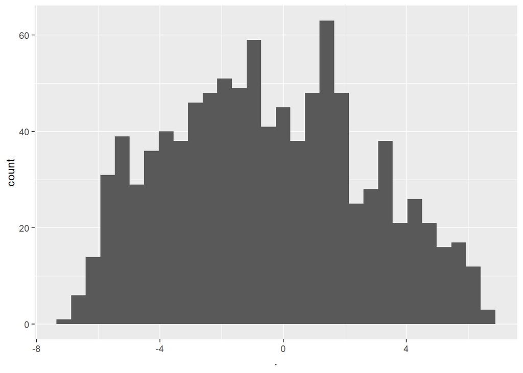

```r
factor_value <- KOR_value %>%
  mutate(across(everything(), ~min_rank(.))) %>%
  mutate(across(everything(), ~scale(.))) %>%
  rowSums()

factor_value %>%
  data.frame() %>%
  ggplot(aes(x = `.`)) +
  geom_histogram()
```

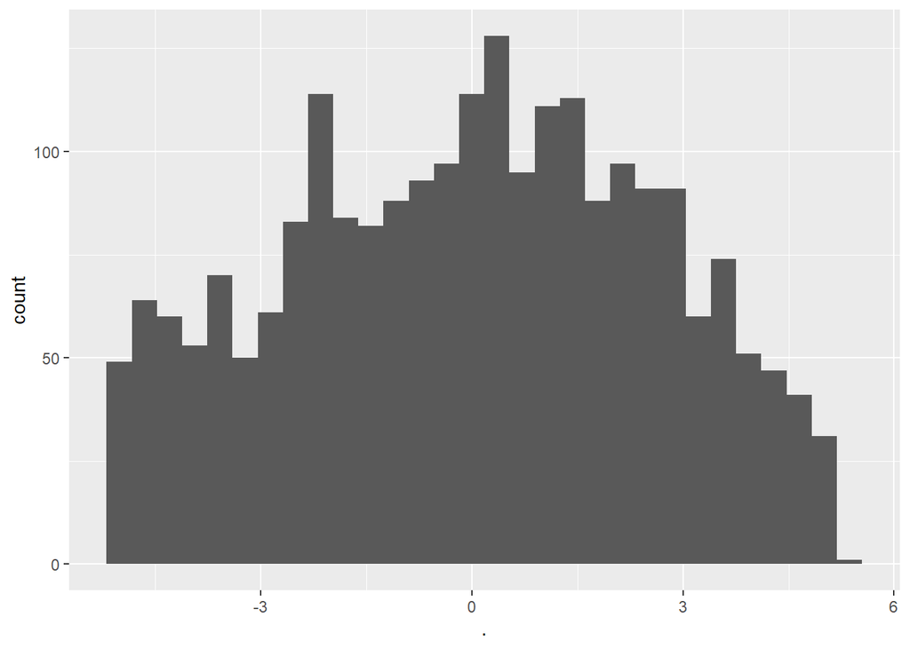

```r
# Construct mom factor

library(PerformanceAnalytics)
library(dplyr)

ret_3m = Return.calculate(KOR_price) %>% xts::last(60) %>%
  sapply(., function(x) {prod(1+x) - 1})
ret_6m = Return.calculate(KOR_price) %>% xts::last(120) %>%
  sapply(., function(x) {prod(1+x) - 1})
ret_12m = Return.calculate(KOR_price) %>% xts::last(252) %>%
  sapply(., function(x) {prod(1+x) - 1})
ret_bind = cbind(ret_3m, ret_6m, ret_12m) %>% data.frame()

factor_mom = ret_bind %>%
  mutate(across(everything(),~min_rank(desc(.)))) %>%
  mutate(across(everything(), ~scale(.))) %>%
  rowSums()

factor_mom %>%
  data.frame() %>%
  ggplot(aes(x = `.`)) +
  geom_histogram()
```

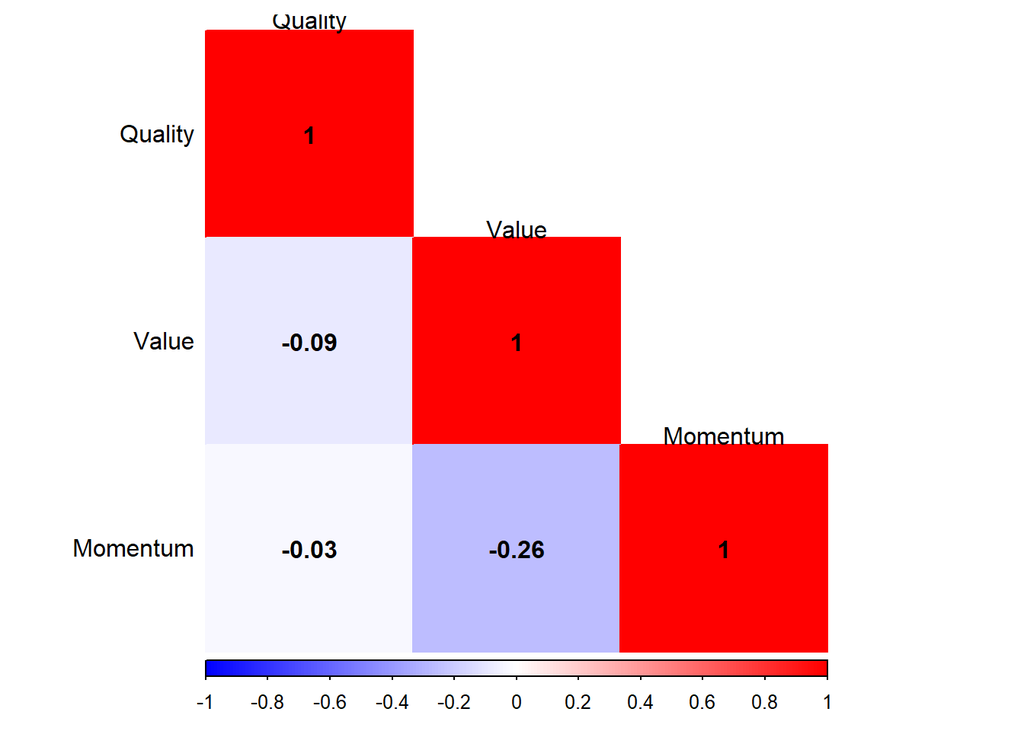

```r
library(corrplot)

cbind(factor_quality, factor_value, factor_mom) %>%
  data.frame() %>%
  setNames(c('Quality', 'Value', 'Momentum')) %>%
  cor(use = 'complete.obs') %>%
  round(.,2) %>%
  corrplot(method = 'color', type = "lower", addCoef.col = 'black', number.cex = 1, tl.cex = 1, tl.srt = 0, tl.col = 'black',
           col =
             colorRampPalette(c('blue', 'white', 'red'))(200),
           mar=c(0,0,0.5,0))
```

##### Remarks

- We see that value, quality, and momentum have low correlations, so using these together to construct a multi-factor portfolio should benefit from diversification.

```r
# scale again to make distribution even and then use equal weighting scheme to get weighted average ranks for multi-factor portfolio
factor_qvm =
cbind(factor_quality, factor_value, factor_mom) %>%
data.frame() %>%
mutate(across(everything(), ~scale(.))) %>%
mutate(factor_quality = factor_quality * 0.33,
       factor_value = factor_value * 0.33,
       factor_mom = factor_mom * 0.33) %>%
rowSums()

invest_qvm = rank(factor_qvm) <= 30

head(invest_qvm)
```

```
## 320000 145210 010580 000250 131100 051980
##  FALSE  FALSE  FALSE  FALSE  FALSE  FALSE
```

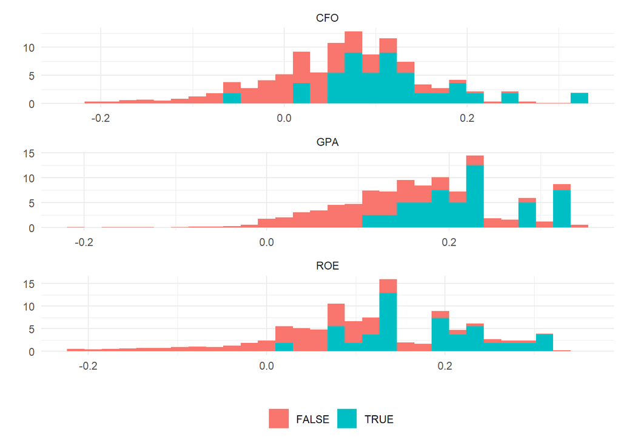

```r
cbind(quality_comb, invest_qvm) %>%
  as.data.frame() %>%
  pivot_longer(cols = -invest_qvm, names_to = "key", values_to = "value") %>%
  mutate(
    value = ifelse(percent_rank(value) > 0.95, NA, value),
    value = ifelse(percent_rank(value) < 0.05, NA, value)
  ) %>% # Trim outliers
  ggplot(aes(x = value, fill = as.factor(invest_qvm))) +
  geom_histogram(aes(y = ..density..), bins = 30) + #..density to scale to 1
  facet_wrap(~ key, scales = "free", ncol = 1) +
  theme_minimal() +
  theme(legend.position = "bottom") +
  labs(x = "", y = "", fill = '')
```

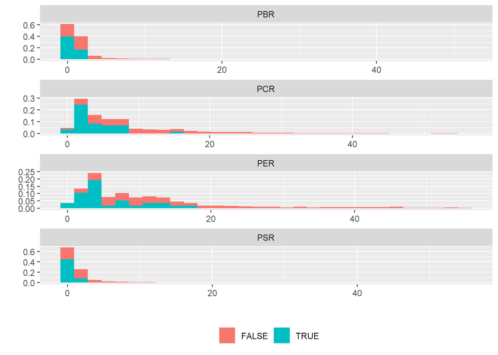

```r
cbind(KOR_value, invest_qvm) %>%
  pivot_longer(cols = -invest_qvm, names_to = "key", values_to = "value") %>%
  mutate(value = ifelse(percent_rank(value) > 0.95, NA, value),
         value = ifelse(percent_rank(value) < 0.05, NA, value)) %>%
  ggplot(aes(x = value, fill = as.factor(invest_qvm))) +
  geom_histogram(aes(y = ..density..), bins = 30) +
  facet_wrap(. ~ key, scale = "free", ncol = 1) +
  theme(legend.position = "bottom") +
  labs(x = "", y = "", fill = '')
```

##### Remarks

- Above visualization confirms that the stocks in multi-factor are in general undervalued in terms of valuation metrics.

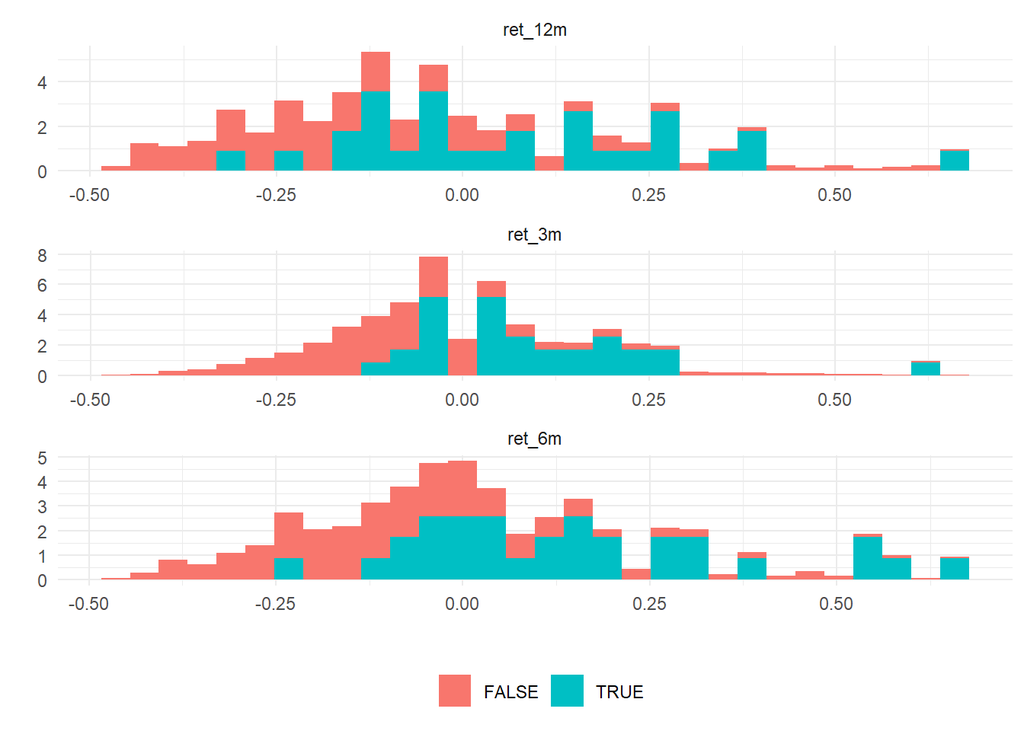

```r
cbind(ret_bind, invest_qvm) %>%
  as.data.frame() %>%
  pivot_longer(cols = -invest_qvm, names_to = "key", values_to = "value") %>%
  mutate(
    value = ifelse(percent_rank(value) > 0.95, NA, value),
    value = ifelse(percent_rank(value) < 0.05, NA, value)
  ) %>%
  ggplot(aes(x = value, fill = as.factor(invest_qvm))) +
  geom_histogram(aes(y = ..density..), bins = 30) +
  facet_wrap(~key, scales = "free", ncol = 1) +
  theme_minimal() +
  theme(legend.position = "bottom") +
  labs(x = "", y = "", fill = "")
```

##### Remarks - Above visualization confirms that the stocks in multi-factor have in general experienced higher returns.

## Reflections

For this section, there were some important details that we had to consider.

1. When calculating market cap for magic formula, we used *PER* data from the *KOR_value* csv sheet. However, there were over 1000 NA values regarding PER data, probably because we used “지배주주순이익” instead of “당기순이익”, and the former account was not used anymore.
2. Should look into constructing long-short portfolios instead of just long-only portfolios.
3. Ranking is a powerful way to standardize factors. However, we must be careful to not aggregate ranks with widely differing ranges. In such case, we should standardize ranks before adding them up. Rank –> Scale –> Cross-sectional Aggregation –> Rank –> Cross-sectional Aggregation is the general flow for constructing multi-factor portfolio.
4. Verify the selected names are consistent with out methodology.